# Final_ClaireKelley_12_17_14

Claire Kelley

Wednesday, December 17, 2014

First, load in the data and examine.

```r
load("C:/Users/Esmail/Desktop/Claire/Sociology/Varoon/WorkspaceClaireJune10.RData")
head(x)
```

```
##      post_id suburb website   city   state  age            location
## 1 3960826754    m4m  auburn auburn Alabama   22              Auburn
## 2 3959244561    m4m  auburn auburn Alabama   24              Auburn
## 3 3915660635    m4m  auburn auburn Alabama   47 Auburn/Opelika Area
## 4 3960414867    m4m  auburn auburn Alabama <NA>            Lagrange
## 5 3964466015    m4m  auburn auburn Alabama <NA>                <NA>
## 6 3964440151    m4m  auburn auburn Alabama <NA>            Lagrange
##   post_is_neighboring post_neighbor_city post_neighbor_suburb   pic
## 1               FALSE                 NA                   NA FALSE
## 2               FALSE                 NA                   NA FALSE
## 3               FALSE                 NA                   NA FALSE
## 4               FALSE                 NA                   NA  TRUE
## 5               FALSE                 NA                   NA FALSE
## 6               FALSE                 NA                   NA  TRUE
##                                         title
```

[output cut: 27 more lines]

```r
names(x)
```

```
##  [1] "post_id"              "suburb"               "website"
##  [4] "city"                 "state"                "age"
##  [7] "location"             "post_is_neighboring"  "post_neighbor_city"
## [10] "post_neighbor_suburb" "pic"                  "title"
## [13] "msg"                  "date_orig"            "date_updated"
## [16] "TitleHIV"             "messHIV"              "LTR"
## [19] "SfSex"
```

Next data processing. First, Add dates and days of the week

```r
##split up date variable to exclude time stamp
df<-strsplit(as.character(x$date_orig),",")
h<-sapply(df, "[", 1)
Date<-as.Date(h)

##bind date vector onto data
x<-cbind(x,Date)

##Calcuate Date
Day<-format(x$Date, format="%a")
x<-cbind(x,Day)
```

Add a logical vector for whether the ad mentions safe sex under the label “Safe” there is a seperate concept that we also want to measure- ie ads that mention being disease free or clean. Any ad that mentions “Clean”, “ddf”, “df” is scored as being “clean”

```r
Safe<-grepl("safe", x[,13], ignore.case = TRUE, perl = FALSE, fixed = FALSE, useBytes = FALSE)

##any ad that mentions either clean, ddf or df is coded as clean
c<-grepl("clean", x[,13], ignore.case = TRUE, perl = FALSE, fixed = FALSE, useBytes = FALSE)
d<-grepl("ddf", x[,13], ignore.case = TRUE, perl = FALSE, fixed = FALSE, useBytes = FALSE)
f<-grepl("df", x[,13], ignore.case = TRUE, perl = FALSE, fixed = FALSE, useBytes = FALSE)

clean<-unique(c,d,f)

x<-cbind(x,Safe, clean)

##also label which adds are both
n<-which(x$Safe==T&x$clean==T)
Both<-rep(FALSE,dim(x)[1])
Both[n]<-TRUE
x<-cbind(x,Both)
```

Data is messy. Something odd has happened with the time of data collection A time series appears below

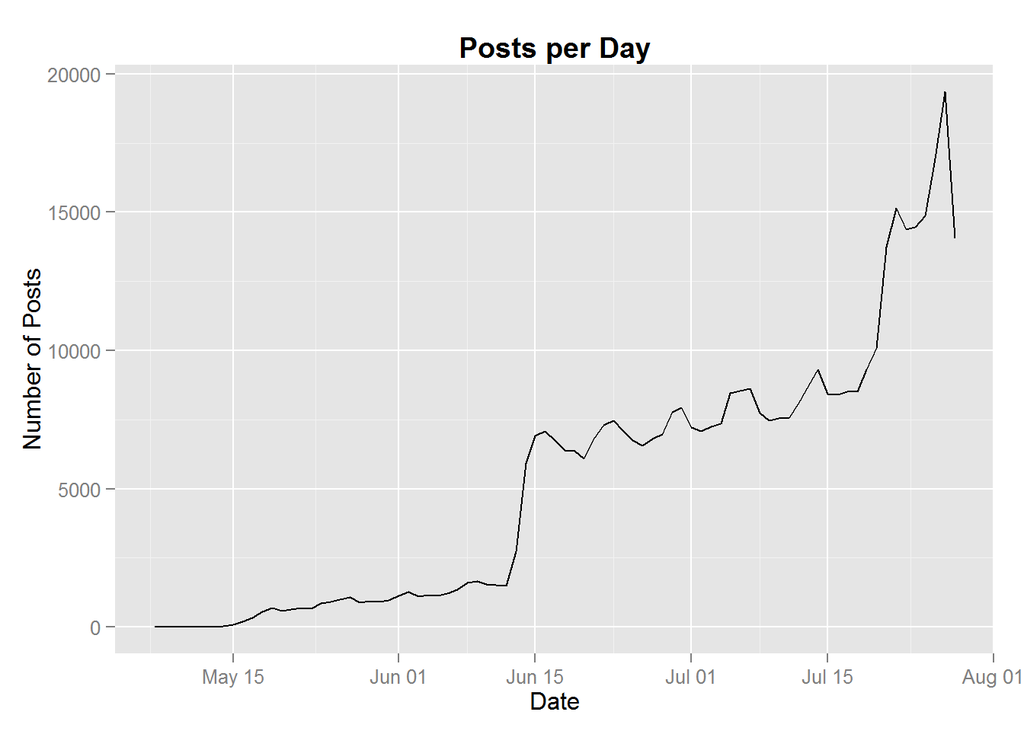

```r
library(ggplot2)
df<-data.frame(table(x$Date))
df$Var1<-as.Date(df$Var1)
 ggplot(data=df, aes(x=Var1, y=Freq,group=1)) + geom_line()+ggtitle("Posts per Day")+scale_y_continuous(name="Number of Posts")+xlab("Date")+theme(plot.title = element_text(lineheight=3, face="bold"))
```

Next we can look at posting seperately by day of the week

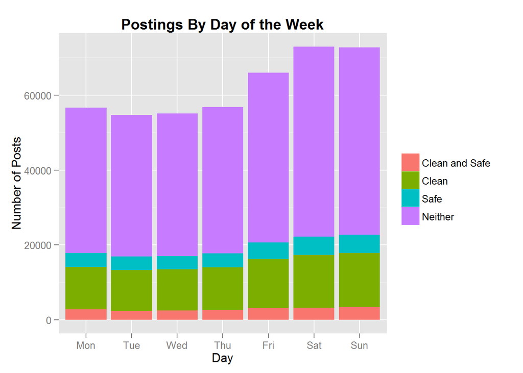

The trend of higher posting rates on the weekend is reflected in the data. Still not sure why the number of posting is increasing like that. Now lets look at state by state posting (Need to reorder)

Next we look at posts mentioning “Clean” or “Safe” over time to see if there are any major trends in these two dimensions. We consider “clean” and “Safe” separately because using protection vs hoping that your partner is being honest about thier STD status have different implication for public health.

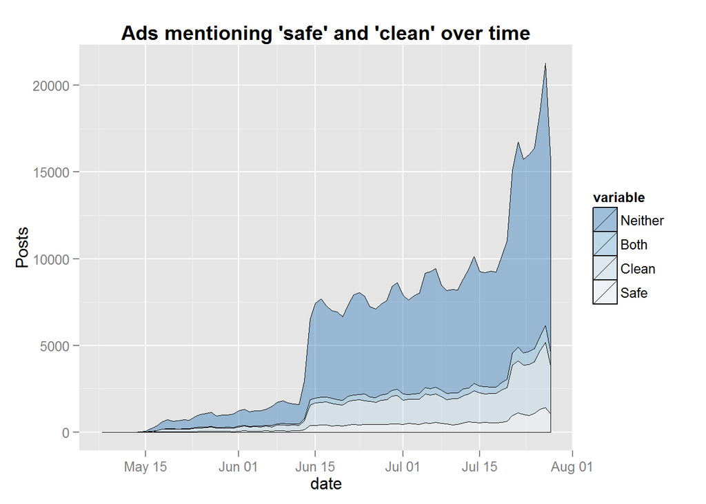

```r
n<-which(x$Safe==T&x$clean==T)

Both<-rep(FALSE,dim(x)[1])

Both[n]<-TRUE
x<-cbind(x,Both)

Day<-matrix(nrow=78,ncol=7)
Day[,1]<-table(x$Safe,x$Date)[2,]
Day[,2]<-table(x$clean,x$Date)[2,]
Day[,3]<-table(x$Both,x$Date)[2,]
Day[,4]<-table(x$Date)
Day<-data.frame(Day)
names(Day)<-c("Safe","Clean","Both","Total")

Day$Safe<-Day$Safe-Day$Both
Day$Clean<-Day$Clean-Day$Both
Day$Neither<-Day$Total-Day$Clean-Day$Safe+Day$Both

mf<-Day[,c("Safe","Clean","Both","Neither")]
tomelt<-data.frame(table(x$Date))
mf<-cbind(tomelt$Var1,mf)
names(mf)[1]<-"date"
mf$date<-as.Date(mf$date)

mf<-melt(mf,id="date")


ggplot(mf, aes(x=date, y=value, fill=variable)) +
  geom_area(colour="black", size=.2, alpha=.4) +
  scale_fill_brewer(palette="Blues", breaks=rev(levels(mf$variable)))+ylab("Posts")+ggtitle("Ads mentioning 'safe' and 'clean' over time")+theme(plot.title = element_text(lineheight=3, face="bold"))
```

Now we move to an examination of geography. The next plot shows post volume by state, colored by percent seeking safe sex

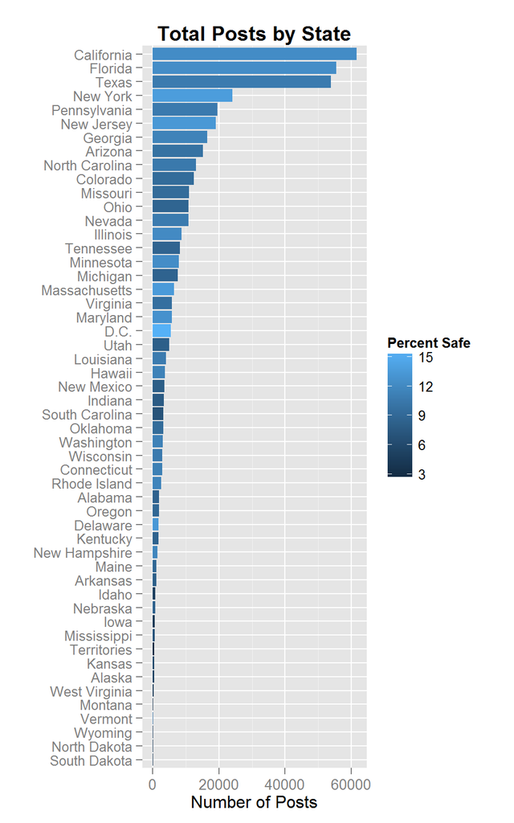

Next we look at Map of safe postings by county

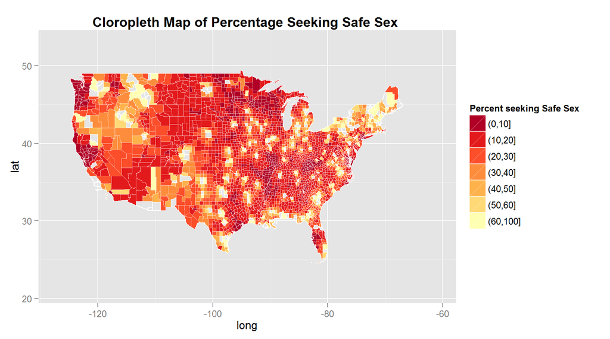

```r
##Load in spatial data from shapefile
library(maptools)
#library (spdep)
#library(spgwr)
setwd("C:/Users/Esmail/Desktop/Claire/Columbia/2_GIS Spatial/Project/Regression")
USASafe <- readShapeSpatial("CountyDataForRegression3")
library(ggplot2)
USA.f <- fortify(USASafe,groups="county")
### Merge in percent safe by county to fortified data set
library(scales)
pp<-cbind(unique(USA.f$id),USASafe$perSafe)
pp<-data.frame(pp)
names(pp)<-c("id","Safe")
USA.g<-merge(USA.f,pp,by="id")

##quantize percent safe for plotting
library(RColorBrewer)
USA.g$cut<-as.numeric(as.character(USA.g$Safe))
USA.g$cut3 <- cut(USA.g$cut, breaks = c(seq(0,60,10),100))
pal<-rev(brewer.pal(7,"YlOrRd"))

##plot clorpleth

ggplot(USA.g, aes(long, lat, group = group)) +
  geom_polygon(data = USA.g, colour = "white", fill = NA) +
  scale_x_continuous(limits=c(-127,-61))+scale_y_continuous(limits=c(21,53))+
  geom_polygon(aes(fill = cut3), colour = alpha("white", 1/2), size = 0.2)+scale_fill_manual(values=pal,name="Percent seeking Safe Sex")+ggtitle("Cloropleth Map of Percentage Seeking Safe Sex ")+theme(plot.title = element_text(lineheight=3, face="bold"))
```

Now we look at the cities with the highest post volume

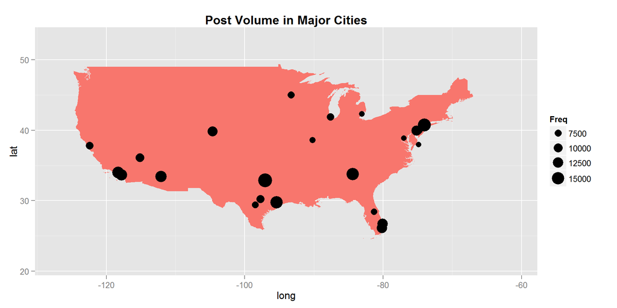

Prep data for text analysis

This line of code wont run in Markdown. It will run in the Console. I cant figure out why and i need the document term matrix organized by date so I ran it in the console, saved it to a file and read it back in for plotting. It is supposed to make a matrix of term frequency by date. I ran this code in the terminal and in the next code chunk read in the csv.

for (i in 3:33){ mat[,(i-2)]<-table(dtm[,i],dtm$Date)[2,] } write.csv(mat,“docterm.csv”)

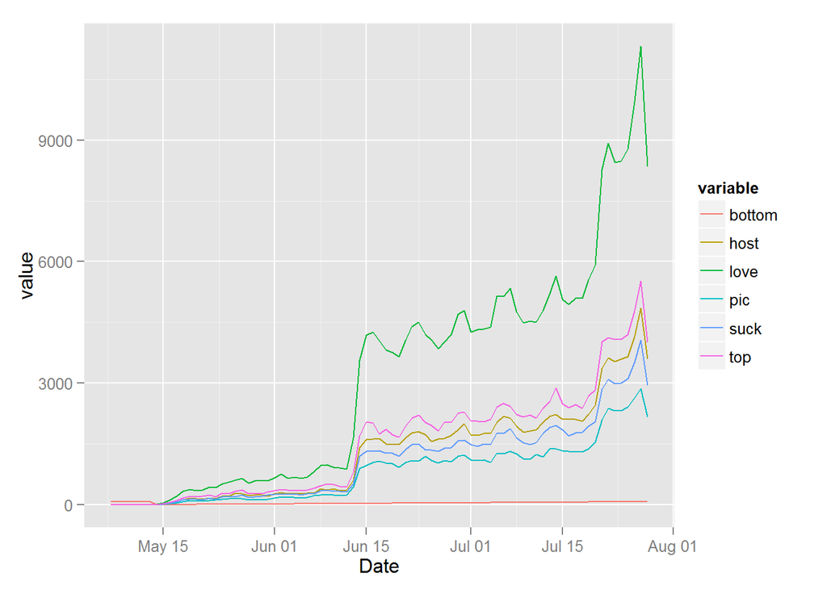

```r
setwd("C:/Users/Esmail/Desktop/Claire/Columbia/4_Data Visualization")
mat<-read.csv("docterm.csv")

dfd<-data.frame(mat)
names(dfd)<-loop[3:33]

dfd<-cbind(as.character(data.frame(table(dtm$Date))[,1]),dfd)
names(dfd)[1]<-"Date"
dfd$Date<-as.Date(dfd$Date)

###sort in date order
dfdS<-dfd[order(dfd$Date),]

##and subset for plotting
tomelt<-dfdS[,c("bottom","host","love","pic","suck","top","Date")]
library(reshape)
dfm<-melt(tomelt,id="Date")
library(ggplot2)
ggplot(data=dfm, aes(x=Date, y=value, group=variable,color=variable)) + geom_line()
```